# Supplementary Software 2

Analysis of optogenetically stimulated glutamate release in Pitx2-Cre STN projections to the Globus Pallidus in mice

Thomas Viereckel

2018-03-15

# 1 Introduction

## 1.1 About the software

Supplementary software 2 consists of 2 parts:  
1. Signal procressing tool  
2. Statistical analysis tool

### 1.1.1 Signal processing tool

The signal processing tool is a R script reading in raw data csv files with the file name format raw[ID].csv and corresponding txt files containing general experimental information and calculated values obtained from the [FAST analysis program](https://fastanalysis.wordpress.com/fast-analysis/) by Jason Burmeister (Version 6.1) in the format s[ID].txt.

Running the signal processing tool generates an output file *output_signalprocessing.RData* containing all calculated values for further analysis. The output file is already included in the package of Supplementary Software 2.

### 1.1.2 Statistical analysis tool

The statistical analysis tool consist of a R markdown file containing R scripts for analysis of the data calculated in the signal processing tool and the [FAST analysis program](https://fastanalysis.wordpress.com/fast-analysis/). This data is imported in the *setup* section on top of the script. Further processing in preparation for statistical analysis is performed in this step as well.

## 1.2 R details

The scripts were written and compiled with R for Windows (64bit) Version 3.3.2 ([The R Project for Statistical Computing](https://www.r-project.org/)) in [RStudio Open Source Edition Version 1.0.136](https://www.rstudio.com/). Data was processed with *plyr* and dcurve fitting performed with *fitdistrplus*. Plots were generated with *ggplot2* and *gridExtra*. Statistical analysis of differences between der experimental groups was performed with routines from *nlme* and *lsmeans*. The R markdown file was compiled to html using *knitr*.

# 2 Rawdata Overview

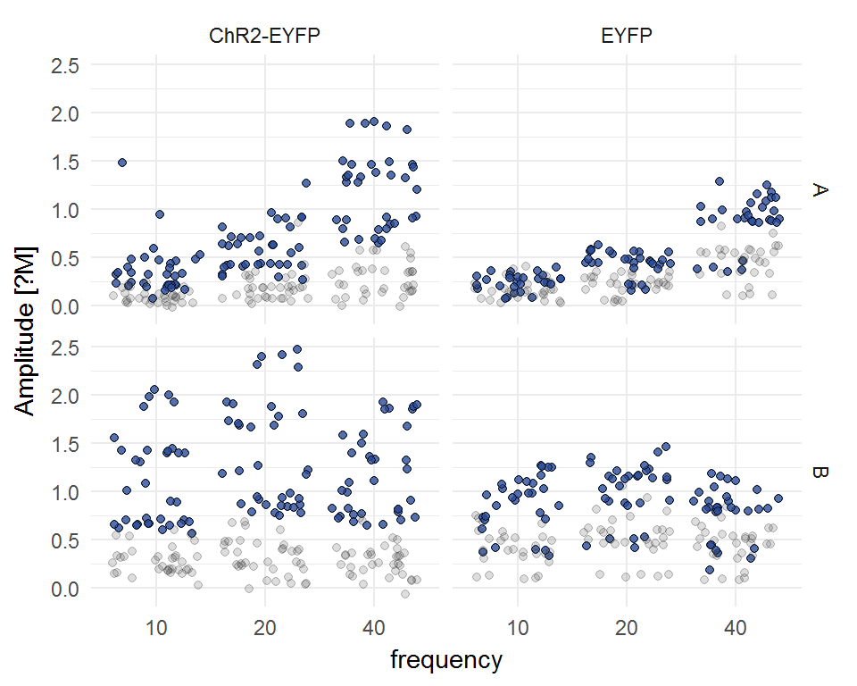

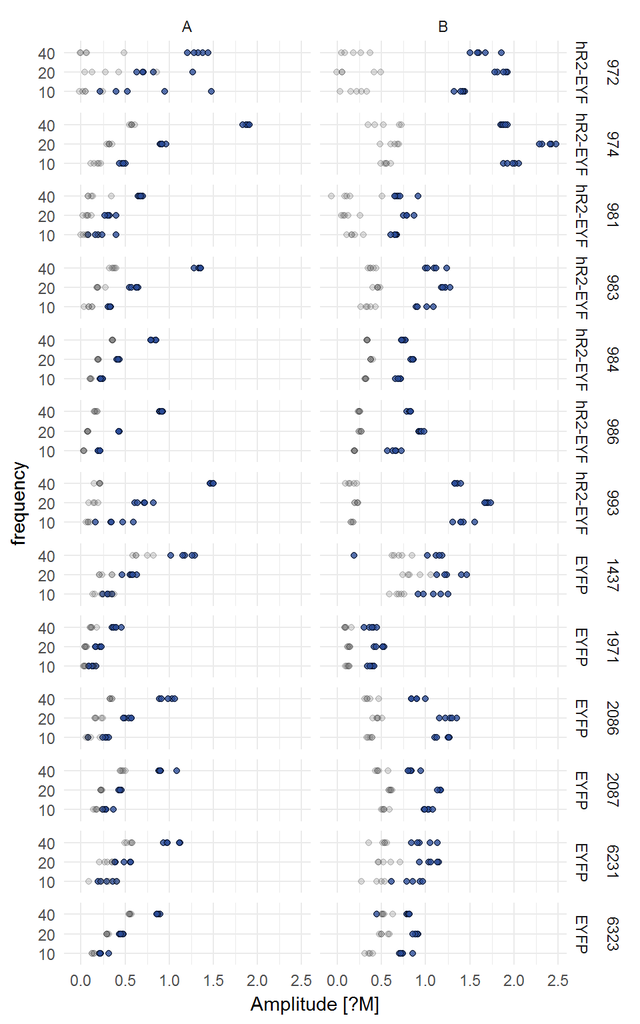

## 2.1 Baseline glutamate values before first stimulation

Of the 13 mice used, 12 possessed a positive baseline value, while in 1, a negative value was recorded. Recordings yielding a negative value were excluded from the calculation of the baseline. The baseline concentration of glutamate in the globus pallidus of the experimental animals was 3.92 ? 1.23 (n=12).

# 3 PROTOCOL A

## 3.1 Amplitude Ĉ0.7 and Ĉ0.25

|  | area | construct | frequency | voltage | genotype | pulse | protocol | stimMs | N2 | Amp | sd | se |
| --- | --- | --- | --- | --- | --- | --- | --- | --- | --- | --- | --- | --- |
| 1 | GPe | ChR2-EYFP | 10 | 0.25 | Pitx2-Cre | 5 | A | 50 | 7 | 0.09 | 0.06 | 0.02 |
| 3 | GPe | ChR2-EYFP | 10 | 0.7 | Pitx2-Cre | 5 | A | 50 | 7 | 0.36 | 0.21 | 0.08 |
| 5 | GPe | ChR2-EYFP | 20 | 0.25 | Pitx2-Cre | 5 | A | 100 | 7 | 0.19 | 0.13 | 0.05 |
| 7 | GPe | ChR2-EYFP | 20 | 0.7 | Pitx2-Cre | 5 | A | 100 | 7 | 0.60 | 0.11 | 0.04 |
| 9 | GPe | ChR2-EYFP | 40 | 0.25 | Pitx2-Cre | 5 | A | 200 | 7 | 0.28 | 0.09 | 0.03 |
| 11 | GPe | ChR2-EYFP | 40 | 0.7 | Pitx2-Cre | 5 | A | 200 | 7 | 1.20 | 0.04 | 0.02 |
| 13 | GPe | EYFP | 10 | 0.25 | Pitx2-Cre | 5 | A | 50 | 6 | 0.17 | 0.08 | 0.03 |
| 15 | GPe | EYFP | 10 | 0.7 | Pitx2-Cre | 5 | A | 50 | 6 | 0.25 | 0.07 | 0.03 |
| 17 | GPe | EYFP | 20 | 0.25 | Pitx2-Cre | 5 | A | 100 | 6 | 0.22 | 0.04 | 0.02 |
| 19 | GPe | EYFP | 20 | 0.7 | Pitx2-Cre | 5 | A | 100 | 6 | 0.44 | 0.05 | 0.02 |
| 21 | GPe | EYFP | 40 | 0.25 | Pitx2-Cre | 5 | A | 200 | 6 | 0.45 | 0.05 | 0.02 |
| 23 | GPe | EYFP | 40 | 0.7 | Pitx2-Cre | 5 | A | 200 | 6 | 0.90 | 0.08 | 0.03 |

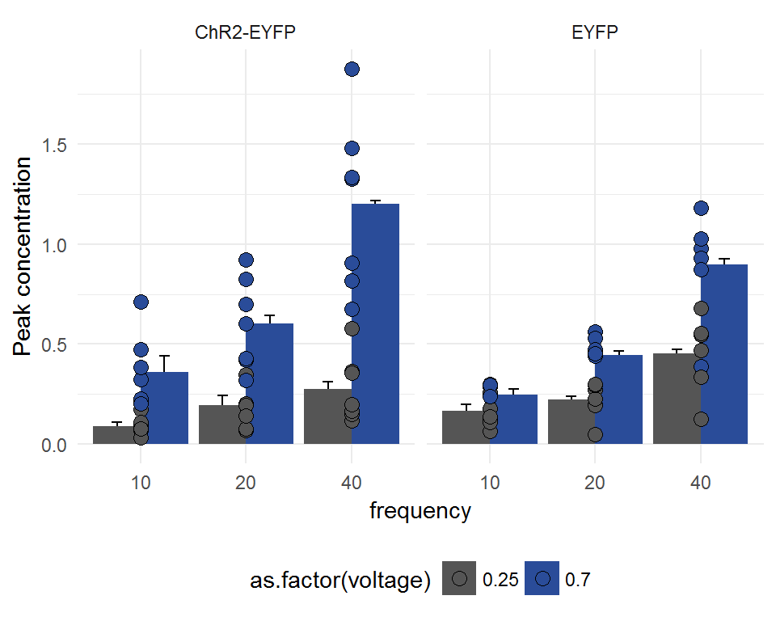

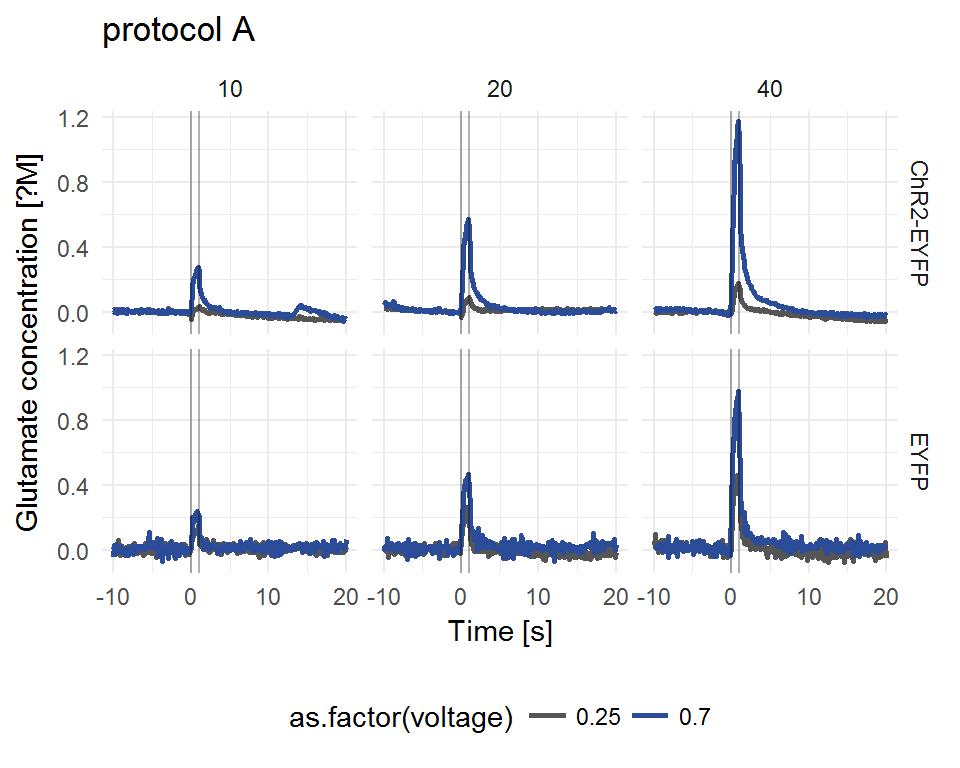

### 3.1.1 ChR2-eYFP animals

The amplitude at +0.7V and +0.25V holding potential is normally distributed for Pitx2-Cre::ChR2-eYFP animals. ANOVA can be performed to evaluate differences between the groups.

|  | statistic | p.value | method |
| --- | --- | --- | --- |
| 10:0.25 | 0.9150 | 0.4314 | Shapiro-Wilk normality test |
| 10:0.7 | 0.8627 | 0.1600 | Shapiro-Wilk normality test |
| 20:0.25 | 0.9151 | 0.4327 | Shapiro-Wilk normality test |
| 20:0.7 | 0.9440 | 0.6750 | Shapiro-Wilk normality test |
| 40:0.25 | 0.8703 | 0.1869 | Shapiro-Wilk normality test |
| 40:0.7 | 0.9457 | 0.6907 | Shapiro-Wilk normality test |

There is a significant difference between the Ĉ0.7 and Ĉ0.25, a significant difference between the amplitudes generated by the different frequencies of stimulation and a difference in the interaction of frequency and voltage. Since the interaction term is significant, the individual factors cannot be meaningfully interpreted.

```
##                   numDF denDF   F-value p-value
## (Intercept)           1    30  53.17465  <.0001
## voltage               1    30 106.06189  <.0001
## frequency             2    30  33.60751  <.0001
## voltage:frequency     2    30  14.56488  <.0001
```

```
## $lsmeans
##  voltage frequency     lsmean         SE df    lower.CL  upper.CL
##  0.25    10        0.08935603 0.08522534  6 -0.11918287 0.2978949
##  0.7     10        0.36239113 0.08522534  6  0.15385223 0.5709300
##  0.25    20        0.19353308 0.08522534  6 -0.01500582 0.4020720
##  0.7     20        0.60267421 0.08522534  6  0.39413531 0.8112131
##  0.25    40        0.27657516 0.08522534  6  0.06803626 0.4851141
##  0.7     40        1.20138800 0.08522534  6  0.99284910 1.4099269
##
## Confidence level used: 0.95
##
## $contrasts
##  contrast             estimate         SE df t.ratio p.value
##  0.25,10 - 0.7,10  -0.27303510 0.09008917 30  -3.031  0.0512
##  0.25,10 - 0.25,20 -0.10417705 0.09008917 30  -1.156  0.8535
##  0.25,10 - 0.7,20  -0.51331818 0.09008917 30  -5.698  <.0001
##  0.25,10 - 0.25,40 -0.18721913 0.09008917 30  -2.078  0.3252
##  0.25,10 - 0.7,40  -1.11203197 0.09008917 30 -12.344  <.0001
##  0.7,10 - 0.25,20   0.16885805 0.09008917 30   1.874  0.4366
##  0.7,10 - 0.7,20   -0.24028308 0.09008917 30  -2.667  0.1122
##  0.7,10 - 0.25,40   0.08581596 0.09008917 30   0.953  0.9291
##  0.7,10 - 0.7,40   -0.83899687 0.09008917 30  -9.313  <.0001
##  0.25,20 - 0.7,20  -0.40914113 0.09008917 30  -4.542  0.0011
##  0.25,20 - 0.25,40 -0.08304209 0.09008917 30  -0.922  0.9378
##  0.25,20 - 0.7,40  -1.00785492 0.09008917 30 -11.187  <.0001
##  0.7,20 - 0.25,40   0.32609905 0.09008917 30   3.620  0.0125
##  0.7,20 - 0.7,40   -0.59871379 0.09008917 30  -6.646  <.0001
##  0.25,40 - 0.7,40  -0.92481283 0.09008917 30 -10.266  <.0001
##
## P value adjustment: tukey method for comparing a family of 6 estimates
```

### 3.1.2 eYFP animals

The amplitude at +0.7V and +0.25V holding potential is normally distributed for Pitx2-Cre::eYFP animals. ANOVA can be performed to evaluate differences between the groups.

|  | statistic | p.value | method |
| --- | --- | --- | --- |
| 10:0.25 | 0.9455 | 0.7034 | Shapiro-Wilk normality test |
| 10:0.7 | 0.8010 | 0.0599 | Shapiro-Wilk normality test |
| 20:0.25 | 0.8396 | 0.1294 | Shapiro-Wilk normality test |
| 20:0.7 | 0.8175 | 0.0839 | Shapiro-Wilk normality test |
| 40:0.25 | 0.9414 | 0.6708 | Shapiro-Wilk normality test |
| 40:0.7 | 0.8515 | 0.1618 | Shapiro-Wilk normality test |

There is a significant difference between the Ĉ0.7 and Ĉ0.25, a significant difference between the amplitudes generated by the different frequencies of stimulation and a difference in the interaction of frequency and voltage. Since the interaction term is significant, the individual factors cannot be meaningfully interpreted.

```
##                   numDF denDF  F-value p-value
## (Intercept)           1    25 57.36917  <.0001
## voltage               1    25 63.92413  <.0001
## frequency             2    25 80.66758  <.0001
## voltage:frequency     2    25 11.50205   3e-04
```

```
## $lsmeans
##  voltage frequency    lsmean         SE df    lower.CL  upper.CL
##  0.25    10        0.1660104 0.06373362  5 0.002177909 0.3298429
##  0.7     10        0.2474485 0.06373362  5 0.083616065 0.4112810
##  0.25    20        0.2234131 0.06373362  5 0.059580638 0.3872456
##  0.7     20        0.4438611 0.06373362  5 0.280028668 0.6076936
##  0.25    40        0.4523878 0.06373362  5 0.288555373 0.6162203
##  0.7     40        0.8955355 0.06373362  5 0.731703048 1.0593680
##
## Confidence level used: 0.95
##
## $contrasts
##  contrast              estimate         SE df t.ratio p.value
##  0.25,10 - 0.7,10  -0.081438156 0.05380009 25  -1.514  0.6591
##  0.25,10 - 0.25,20 -0.057402729 0.05380009 25  -1.067  0.8897
##  0.25,10 - 0.7,20  -0.277850758 0.05380009 25  -5.165  0.0003
##  0.25,10 - 0.25,40 -0.286377463 0.05380009 25  -5.323  0.0002
##  0.25,10 - 0.7,40  -0.729525139 0.05380009 25 -13.560  <.0001
##  0.7,10 - 0.25,20   0.024035427 0.05380009 25   0.447  0.9975
##  0.7,10 - 0.7,20   -0.196412603 0.05380009 25  -3.651  0.0136
##  0.7,10 - 0.25,40  -0.204939308 0.05380009 25  -3.809  0.0093
##  0.7,10 - 0.7,40   -0.648086983 0.05380009 25 -12.046  <.0001
##  0.25,20 - 0.7,20  -0.220448029 0.05380009 25  -4.098  0.0046
##  0.25,20 - 0.25,40 -0.228974734 0.05380009 25  -4.256  0.0031
##  0.25,20 - 0.7,40  -0.672122410 0.05380009 25 -12.493  <.0001
##  0.7,20 - 0.25,40  -0.008526705 0.05380009 25  -0.158  1.0000
##  0.7,20 - 0.7,40   -0.451674381 0.05380009 25  -8.395  <.0001
##  0.25,40 - 0.7,40  -0.443147676 0.05380009 25  -8.237  <.0001
##
## P value adjustment: tukey method for comparing a family of 6 estimates
```

## 3.2 Peak glutamate concentration Ĉglu

|  | area | construct | frequency | voltage | genotype | pulse | protocol | stimMs | N2 | mean | sd | se |
| --- | --- | --- | --- | --- | --- | --- | --- | --- | --- | --- | --- | --- |
| 1 | GPe | ChR2-EYFP | 10 | 0.7 | Pitx2-Cre | 5 | A | 50 | 7 | 0.27 | 0.21 | 0.08 |
| 3 | GPe | ChR2-EYFP | 20 | 0.7 | Pitx2-Cre | 5 | A | 100 | 7 | 0.41 | 0.16 | 0.06 |
| 5 | GPe | ChR2-EYFP | 40 | 0.7 | Pitx2-Cre | 5 | A | 200 | 7 | 0.92 | 0.10 | 0.04 |
| 7 | GPe | EYFP | 10 | 0.7 | Pitx2-Cre | 5 | A | 50 | 6 | 0.08 | 0.10 | 0.04 |
| 9 | GPe | EYFP | 20 | 0.7 | Pitx2-Cre | 5 | A | 100 | 6 | 0.22 | 0.07 | 0.03 |
| 11 | GPe | EYFP | 40 | 0.7 | Pitx2-Cre | 5 | A | 200 | 6 | 0.44 | 0.09 | 0.04 |

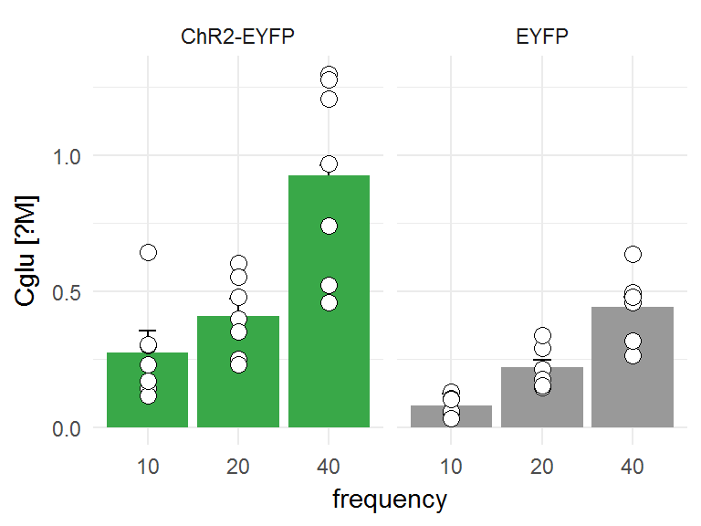

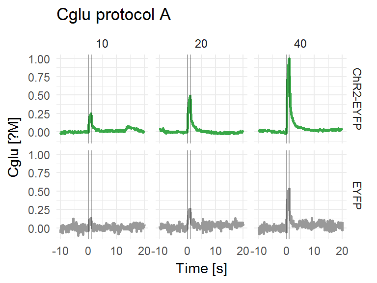

The peak glutamate concentration Ĉglu is normally distributed in Pitx2-Cre::ChR2-eYFP and Pitx2-Cre::eYFP animals for all frequencies in protocol A. ANOVA can be performed to evaluate differences between the groups.

|  | statistic | p.value | method |
| --- | --- | --- | --- |
| 10:ChR2-EYFP | 0.8111 | 0.0526 | Shapiro-Wilk normality test |
| 10:EYFP | 0.9297 | 0.5780 | Shapiro-Wilk normality test |
| 20:ChR2-EYFP | 0.9443 | 0.6781 | Shapiro-Wilk normality test |
| 20:EYFP | 0.8940 | 0.3395 | Shapiro-Wilk normality test |
| 40:ChR2-EYFP | 0.8821 | 0.2359 | Shapiro-Wilk normality test |
| 40:EYFP | 0.9475 | 0.7198 | Shapiro-Wilk normality test |

There is a significant difference between the ChR2-eYFP and eYFP injected mice, a significant difference between the frequencies and a significant difference in the increase over the frequencies throughout the constructs for protocol A. Since the interaction term is significant, the individual factors cannot be meaningfully interpreted.

```
##                     numDF denDF  F-value p-value
## (Intercept)             1    22 79.15039  <.0001
## construct               1    11  9.99574  0.0091
## frequency               2    22 63.50403  <.0001
## construct:frequency     2    22  6.21188  0.0073
```

```
## $lsmeans
##  construct frequency     lsmean         SE df    lower.CL  upper.CL
##  ChR2-EYFP 10        0.27303510 0.07221483 12  0.11569251 0.4303777
##  EYFP      10        0.08143816 0.07800093 11 -0.08851127 0.2513876
##  ChR2-EYFP 20        0.40914113 0.07221483 12  0.25179854 0.5664837
##  EYFP      20        0.22044803 0.07800093 11  0.05049861 0.3903975
##  ChR2-EYFP 40        0.92481283 0.07221483 12  0.76747024 1.0821554
##  EYFP      40        0.44314768 0.07800093 11  0.27319825 0.6130971
##
## Confidence level used: 0.95
##
## $contrasts
##  contrast                       estimate         SE df t.ratio p.value
##  ChR2-EYFP,10 - EYFP,10       0.19159694 0.10629735 11   1.802  0.5014
##  ChR2-EYFP,10 - ChR2-EYFP,20 -0.13610604 0.06488307 22  -2.098  0.3243
##  ChR2-EYFP,10 - EYFP,20       0.05258707 0.10629735 11   0.495  0.9954
##  ChR2-EYFP,10 - ChR2-EYFP,40 -0.65177774 0.06488307 22 -10.045  <.0001
##  ChR2-EYFP,10 - EYFP,40      -0.17011258 0.10629735 11  -1.600  0.6145
##  EYFP,10 - ChR2-EYFP,20      -0.32770298 0.10629735 11  -3.083  0.0842
##  EYFP,10 - EYFP,20           -0.13900987 0.07008173 22  -1.984  0.3824
##  EYFP,10 - ChR2-EYFP,40      -0.84337468 0.10629735 11  -7.934  0.0001
##  EYFP,10 - EYFP,40           -0.36170952 0.07008173 22  -5.161  0.0005
##  ChR2-EYFP,20 - EYFP,20       0.18869310 0.10629735 11   1.775  0.5163
##  ChR2-EYFP,20 - ChR2-EYFP,40 -0.51567170 0.06488307 22  -7.948  <.0001
##  ChR2-EYFP,20 - EYFP,40      -0.03400654 0.10629735 11  -0.320  0.9994
##  EYFP,20 - ChR2-EYFP,40      -0.70436480 0.10629735 11  -6.626  0.0004
##  EYFP,20 - EYFP,40           -0.22269965 0.07008173 22  -3.178  0.0438
##  ChR2-EYFP,40 - EYFP,40       0.48166516 0.10629735 11   4.531  0.0084
##
## P value adjustment: tukey method for comparing a family of 6 estimates
```

### 3.2.1 Clearance phase

|  | genotype | construct | protocol | pulse | frequency | correction | Trise | Tstart | a1 | a0 | r2_linear | lambda | tau | b | r2 |
| --- | --- | --- | --- | --- | --- | --- | --- | --- | --- | --- | --- | --- | --- | --- | --- |
| 1 | Pitx2-Cre | ChR2-EYFP | A | 5 | 10 | 0 | 1 | 1.5 | -0.26 | 0.45 | 0.81 | -0.26 | 3.92 | -2.37 | 0.33 |
| 2 | Pitx2-Cre | ChR2-EYFP | A | 5 | 20 | 0 | 1 | 1.5 | -0.51 | 0.88 | 0.78 | -0.95 | 1.05 | -0.49 | 0.96 |
| 3 | Pitx2-Cre | ChR2-EYFP | A | 5 | 40 | 0 | 1 | 1.5 | -1.17 | 1.96 | 0.82 | -0.82 | 1.22 | -0.03 | 0.99 |
| 7 | Pitx2-Cre | EYFP | A | 5 | 10 | 0 | 1 | 1.5 | -0.16 | 0.23 | 0.50 | 0.09 | -11.06 | -4.36 | -0.98 |
| 8 | Pitx2-Cre | EYFP | A | 5 | 20 | 0 | 1 | 1.5 | -0.24 | 0.41 | 0.52 | -0.58 | 1.72 | -1.58 | -0.13 |
| 9 | Pitx2-Cre | EYFP | A | 5 | 40 | 0 | 1 | 1.5 | -0.34 | 0.58 | 0.69 | -0.62 | 1.62 | -1.34 | -0.11 |

## 3.3 Amplitude/Artifact ratio (AR)

The amplitude/artifact ratio is a measure of the size of the glutamate release compared to the laser-induced artifact.

|  | area | construct | frequency | voltage | genotype | pulse | protocol | stimMs | N2 | mean | sd | se |
| --- | --- | --- | --- | --- | --- | --- | --- | --- | --- | --- | --- | --- |
| 1 | GPe | ChR2-EYFP | 10 | 0.7 | Pitx2-Cre | 5 | A | 50 | 7 | 4.66 | 0.21 | 0.08 |
| 3 | GPe | ChR2-EYFP | 20 | 0.7 | Pitx2-Cre | 5 | A | 100 | 7 | 3.64 | 0.16 | 0.06 |
| 5 | GPe | ChR2-EYFP | 40 | 0.7 | Pitx2-Cre | 5 | A | 200 | 7 | 5.37 | 0.10 | 0.04 |
| 7 | GPe | EYFP | 10 | 0.7 | Pitx2-Cre | 5 | A | 50 | 6 | 1.64 | 0.10 | 0.04 |
| 9 | GPe | EYFP | 20 | 0.7 | Pitx2-Cre | 5 | A | 100 | 6 | 2.28 | 0.07 | 0.03 |
| 11 | GPe | EYFP | 40 | 0.7 | Pitx2-Cre | 5 | A | 200 | 6 | 2.19 | 0.09 | 0.04 |

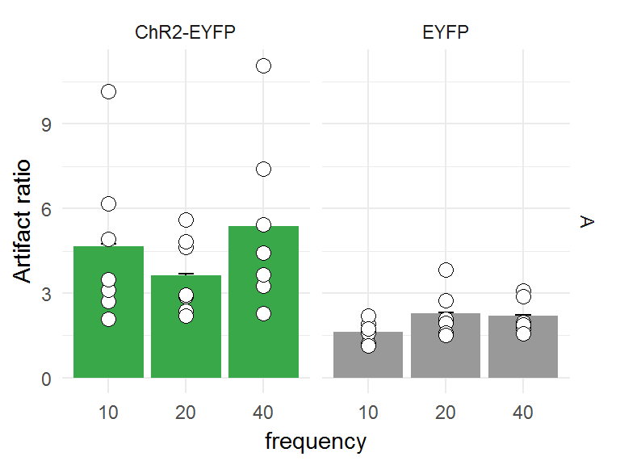

The amplitude/artifact ratio is normally distributed in Pitx2-Cre::ChR2-eYFP and Pitx2-Cre::eYFP animals for all frequencies in protocol A. ANOVA can be performed to evaluate differences between the groups.

|  | statistic | p.value | method |
| --- | --- | --- | --- |
| 10:ChR2-EYFP | 0.8578 | 0.1447 | Shapiro-Wilk normality test |
| 10:EYFP | 0.9562 | 0.7904 | Shapiro-Wilk normality test |
| 20:ChR2-EYFP | 0.8830 | 0.2400 | Shapiro-Wilk normality test |
| 20:EYFP | 0.8689 | 0.2217 | Shapiro-Wilk normality test |
| 40:ChR2-EYFP | 0.8958 | 0.3066 | Shapiro-Wilk normality test |
| 40:EYFP | 0.8448 | 0.1427 | Shapiro-Wilk normality test |

There is a significant difference in the AR between the two constructs. AR is independent of the frequency of the stimulation in protocol A. No PostHoc test is needed, as there only are two viral constructs.

```
##                     numDF denDF  F-value p-value
## (Intercept)             1    22 64.85045  <.0001
## construct               1    11  8.87760  0.0125
## frequency               2    22  1.39940  0.2679
## construct:frequency     2    22  1.69552  0.2066
```

## 3.4 Glutamate concentration normalized to milliseconds of stimulation (ΔCt)

The stimulations at 10, 20 and 40 Hz with a constant pulse length of 5 ms in protocol A produce different duty cycles and therefore total stimulations times. To be able to compare the efficiency of the stimulation for each frequency in the protocol, the Ĉglu needs to be normalized. The peak glutamate concentration per ms stimulation (ΔCt) is a measure for this.

|  | area | construct | frequency | voltage | genotype | pulse | protocol | stimMs | N2 | mean | sd | se |
| --- | --- | --- | --- | --- | --- | --- | --- | --- | --- | --- | --- | --- |
| 1 | GPe | ChR2-EYFP | 10 | 0.7 | Pitx2-Cre | 5 | A | 50 | 7 | 5.46 | 4.27 | 1.61 |
| 3 | GPe | ChR2-EYFP | 20 | 0.7 | Pitx2-Cre | 5 | A | 100 | 7 | 4.09 | 1.64 | 0.62 |
| 5 | GPe | ChR2-EYFP | 40 | 0.7 | Pitx2-Cre | 5 | A | 200 | 7 | 4.62 | 0.50 | 0.19 |
| 7 | GPe | EYFP | 10 | 0.7 | Pitx2-Cre | 5 | A | 50 | 6 | 1.63 | 2.07 | 0.85 |
| 9 | GPe | EYFP | 20 | 0.7 | Pitx2-Cre | 5 | A | 100 | 6 | 2.20 | 0.66 | 0.27 |
| 11 | GPe | EYFP | 40 | 0.7 | Pitx2-Cre | 5 | A | 200 | 6 | 2.22 | 0.45 | 0.18 |

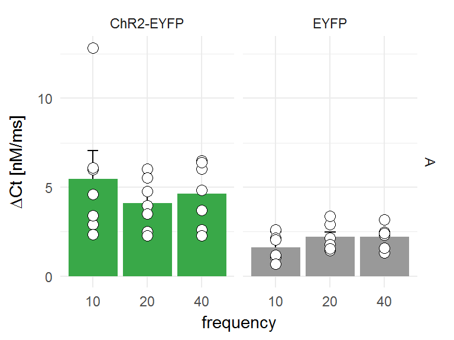

ΔCt is normally distributed in Pitx2-Cre::ChR2-eYFP and Pitx2-Cre::eYFP animals for all frequencies in protocol A. ANOVA can be performed to evaluate differences between the groups.

|  | statistic | p.value | method |
| --- | --- | --- | --- |
| 10:ChR2-EYFP | 0.8111 | 0.0526 | Shapiro-Wilk normality test |
| 10:EYFP | 0.9297 | 0.5780 | Shapiro-Wilk normality test |
| 20:ChR2-EYFP | 0.9443 | 0.6781 | Shapiro-Wilk normality test |
| 20:EYFP | 0.8940 | 0.3395 | Shapiro-Wilk normality test |
| 40:ChR2-EYFP | 0.8821 | 0.2359 | Shapiro-Wilk normality test |
| 40:EYFP | 0.9475 | 0.7198 | Shapiro-Wilk normality test |

There is a significant difference in the ΔCt between the two constructs. ΔCt is independent of the frequency of the stimulation in protocol A. No PostHoc test is needed as there only are two viral constructs.

[output not shown]

## 3.5 Scatterplot summary for ΔCt, AR and Ĉglu

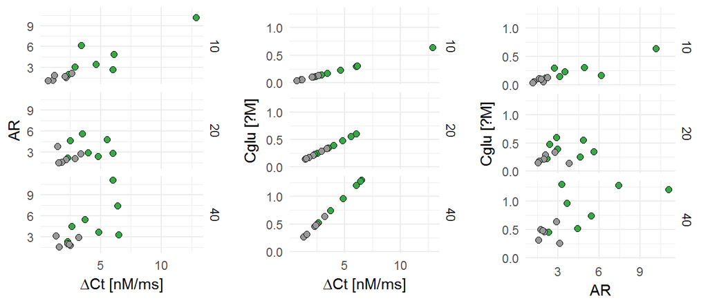

# 4 PROTOCOL B

## 4.1 Amplitude Ĉ0.7 and Ĉ0.25

|  | area | construct | frequency | voltage | genotype | pulse | protocol | stimMs | N2 | Amp | sd | se |
| --- | --- | --- | --- | --- | --- | --- | --- | --- | --- | --- | --- | --- |
| 2 | GPe | ChR2-EYFP | 10 | 0.25 | Pitx2-Cre | 15 | B | 150 | 7 | 0.28 | 0.06 | 0.02 |
| 4 | GPe | ChR2-EYFP | 10 | 0.7 | Pitx2-Cre | 15 | B | 150 | 7 | 1.11 | 0.06 | 0.02 |
| 6 | GPe | ChR2-EYFP | 20 | 0.25 | Pitx2-Cre | 10 | B | 200 | 7 | 0.32 | 0.10 | 0.04 |
| 8 | GPe | ChR2-EYFP | 20 | 0.7 | Pitx2-Cre | 10 | B | 200 | 7 | 1.39 | 0.05 | 0.02 |
| 10 | GPe | ChR2-EYFP | 40 | 0.25 | Pitx2-Cre | 5 | B | 200 | 7 | 0.29 | 0.12 | 0.04 |
| 12 | GPe | ChR2-EYFP | 40 | 0.7 | Pitx2-Cre | 5 | B | 200 | 7 | 1.18 | 0.08 | 0.03 |
| 14 | GPe | EYFP | 10 | 0.25 | Pitx2-Cre | 15 | B | 150 | 6 | 0.42 | 0.06 | 0.02 |
| 16 | GPe | EYFP | 10 | 0.7 | Pitx2-Cre | 15 | B | 150 | 6 | 0.88 | 0.09 | 0.04 |
| 18 | GPe | EYFP | 20 | 0.25 | Pitx2-Cre | 10 | B | 200 | 6 | 0.52 | 0.07 | 0.03 |
| 20 | GPe | EYFP | 20 | 0.7 | Pitx2-Cre | 10 | B | 200 | 6 | 1.02 | 0.08 | 0.03 |
| 22 | GPe | EYFP | 40 | 0.25 | Pitx2-Cre | 5 | B | 200 | 6 | 0.45 | 0.07 | 0.03 |
| 24 | GPe | EYFP | 40 | 0.7 | Pitx2-Cre | 5 | B | 200 | 6 | 0.79 | 0.19 | 0.08 |

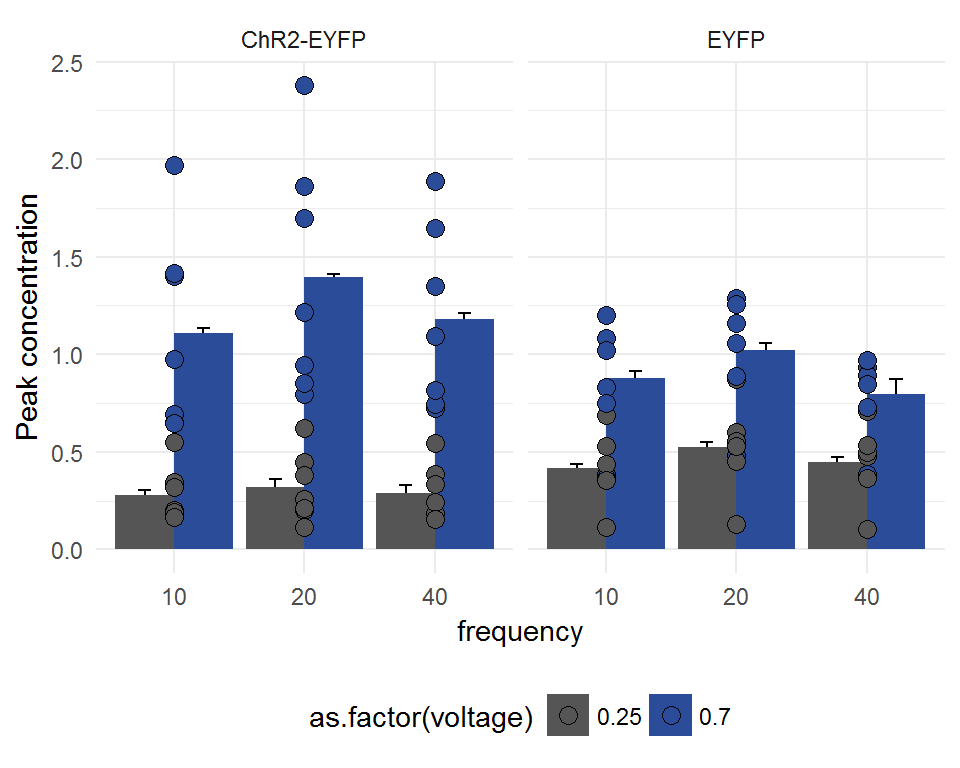

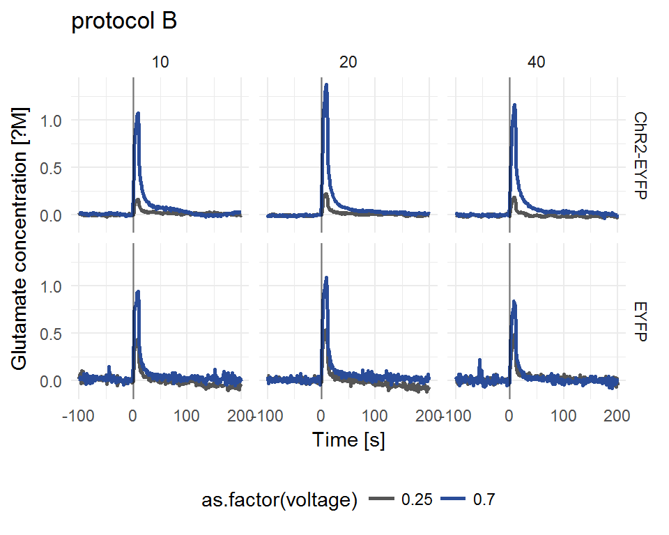

### 4.1.1 ChR2-eYFP animals

The amplitude at +0.7V and +0.25V holding potential is normally distributed for Pitx2-Cre::ChR2-eYFP animals in protocol B. ANOVA can be performed to evaluate differences between the groups.

|  | statistic | p.value | method |
| --- | --- | --- | --- |
| 10:0.25 | 0.8150 | 0.0574 | Shapiro-Wilk normality test |
| 10:0.7 | 0.8705 | 0.1876 | Shapiro-Wilk normality test |
| 20:0.25 | 0.9431 | 0.6672 | Shapiro-Wilk normality test |
| 20:0.7 | 0.9037 | 0.3543 | Shapiro-Wilk normality test |
| 40:0.25 | 0.8939 | 0.2955 | Shapiro-Wilk normality test |
| 40:0.7 | 0.8971 | 0.3136 | Shapiro-Wilk normality test |

There is a significant difference between the Ĉ0.7 and Ĉ0.25.

```
##                   numDF denDF   F-value p-value
## (Intercept)           1    30  43.83279  <.0001
## voltage               1    30 131.24855  <.0001
## frequency             2    30   1.44713  0.2512
## voltage:frequency     2    30   0.81069  0.4541
```

### 4.1.2 eYFP animals

The amplitude at +0.7V and +0.25V holding potential is normally distributed for Pitx2-Cre::eYFP animals in protocol B. ANOVA can be performed to evaluate differences between the groups.

|  | statistic | p.value | method |
| --- | --- | --- | --- |
| 10:0.25 | 0.9730 | 0.9118 | Shapiro-Wilk normality test |
| 10:0.7 | 0.9403 | 0.6616 | Shapiro-Wilk normality test |
| 20:0.25 | 0.9400 | 0.6588 | Shapiro-Wilk normality test |
| 20:0.7 | 0.8739 | 0.2421 | Shapiro-Wilk normality test |
| 40:0.25 | 0.9418 | 0.6739 | Shapiro-Wilk normality test |
| 40:0.7 | 0.8165 | 0.0823 | Shapiro-Wilk normality test |

There is a significant difference between the Ĉ0.7 and Ĉ0.25 and a significant difference between the frequencies

```
##                   numDF denDF   F-value p-value
## (Intercept)           1    25  55.12503  <.0001
## voltage               1    25 148.48182  <.0001
## frequency             2    25   6.86901  0.0042
## voltage:frequency     2    25   1.68677  0.2055
```

```
## $lsmeans
##  voltage frequency    lsmean         SE df  lower.CL  upper.CL
##  0.25    10        0.4157375 0.09997285  5 0.1587491 0.6727259
##  0.7     10        0.8780743 0.09997285  5 0.6210860 1.1350627
##  0.25    20        0.5226255 0.09997285  5 0.2656372 0.7796139
##  0.7     20        1.0229689 0.09997285  5 0.7659805 1.2799573
##  0.25    40        0.4479755 0.09997285  5 0.1909871 0.7049639
##  0.7     40        0.7937908 0.09997285  5 0.5368024 1.0507792
##
## Confidence level used: 0.95
##
## $contrasts
##  contrast             estimate         SE df t.ratio p.value
##  0.25,10 - 0.7,10  -0.46233682 0.06199761 25  -7.457  <.0001
##  0.25,10 - 0.25,20 -0.10688802 0.06199761 25  -1.724  0.5296
##  0.25,10 - 0.7,20  -0.60723136 0.06199761 25  -9.794  <.0001
##  0.25,10 - 0.25,40 -0.03223799 0.06199761 25  -0.520  0.9949
##  0.25,10 - 0.7,40  -0.37805329 0.06199761 25  -6.098  <.0001
##  0.7,10 - 0.25,20   0.35544879 0.06199761 25   5.733  0.0001
##  0.7,10 - 0.7,20   -0.14489455 0.06199761 25  -2.337  0.2170
##  0.7,10 - 0.25,40   0.43009883 0.06199761 25   6.937  <.0001
##  0.7,10 - 0.7,40    0.08428352 0.06199761 25   1.359  0.7497
##  0.25,20 - 0.7,20  -0.50034334 0.06199761 25  -8.070  <.0001
##  0.25,20 - 0.25,40  0.07465004 0.06199761 25   1.204  0.8307
##  0.25,20 - 0.7,40  -0.27116527 0.06199761 25  -4.374  0.0023
##  0.7,20 - 0.25,40   0.57499337 0.06199761 25   9.274  <.0001
##  0.7,20 - 0.7,40    0.22917807 0.06199761 25   3.697  0.0122
##  0.25,40 - 0.7,40  -0.34581530 0.06199761 25  -5.578  0.0001
##
## P value adjustment: tukey method for comparing a family of 6 estimates
```

## 4.2 Peak glutamate concentration Ĉglu

|  | area | construct | frequency | voltage | genotype | pulse | protocol | stimMs | N2 | mean | sd | se |
| --- | --- | --- | --- | --- | --- | --- | --- | --- | --- | --- | --- | --- |
| 2 | GPe | ChR2-EYFP | 10 | 0.7 | Pitx2-Cre | 15 | B | 150 | 7 | 0.83 | 0.09 | 0.03 |
| 4 | GPe | ChR2-EYFP | 20 | 0.7 | Pitx2-Cre | 10 | B | 200 | 7 | 1.07 | 0.11 | 0.04 |
| 6 | GPe | ChR2-EYFP | 40 | 0.7 | Pitx2-Cre | 5 | B | 200 | 7 | 0.89 | 0.14 | 0.05 |
| 8 | GPe | EYFP | 10 | 0.7 | Pitx2-Cre | 15 | B | 150 | 6 | 0.46 | 0.11 | 0.05 |
| 10 | GPe | EYFP | 20 | 0.7 | Pitx2-Cre | 10 | B | 200 | 6 | 0.50 | 0.11 | 0.04 |
| 12 | GPe | EYFP | 40 | 0.7 | Pitx2-Cre | 5 | B | 200 | 6 | 0.35 | 0.21 | 0.08 |

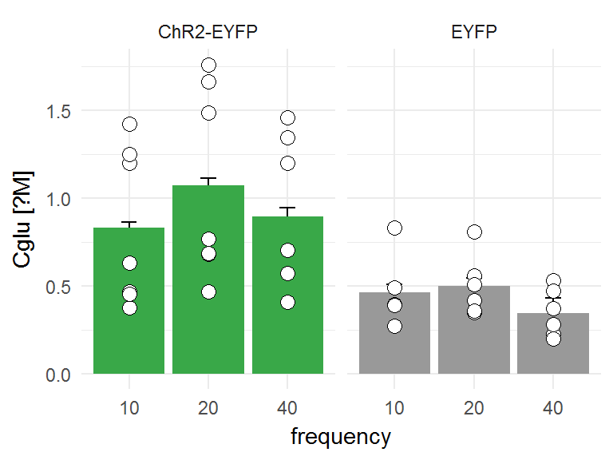

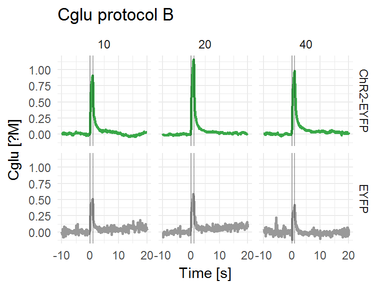

The peak glutamate concentration Ĉglu is normally distributed in Pitx2-Cre::ChR2-eYFP and Pitx2-Cre::eYFP animals for all frequencies in protocol B. ANOVA can be performed to evaluate differences between the groups.

|  | statistic | p.value | method |
| --- | --- | --- | --- |
| 10:ChR2-EYFP | 0.8385 | 0.0963 | Shapiro-Wilk normality test |
| 10:EYFP | 0.8026 | 0.0621 | Shapiro-Wilk normality test |
| 20:ChR2-EYFP | 0.8437 | 0.1075 | Shapiro-Wilk normality test |
| 20:EYFP | 0.8722 | 0.2350 | Shapiro-Wilk normality test |
| 40:ChR2-EYFP | 0.8725 | 0.1953 | Shapiro-Wilk normality test |
| 40:EYFP | 0.9298 | 0.5782 | Shapiro-Wilk normality test |

There is a significant difference between the ChR2-eYFP and eYFP injected mice, a significant difference between the frequencies and a significant difference in the increase over the frequencies throughout the constructs for protocol B. Since the interaction term is significant, the individual factors cannot be meaningfully interpreted.

```
##                     numDF denDF  F-value p-value
## (Intercept)             1    22 49.21434  <.0001
## construct               1    11  6.07324  0.0314
## frequency               2    22 17.13789  <.0001
## construct:frequency     2    22  6.34204  0.0067
```

```
## $lsmeans
##  construct frequency    lsmean        SE df   lower.CL  upper.CL
##  ChR2-EYFP 10        0.8285474 0.1387652 12 0.52620401 1.1308907
##  EYFP      10        0.4623368 0.1498835 11 0.13576866 0.7889050
##  ChR2-EYFP 20        1.0730890 0.1387652 12 0.77074567 1.3754324
##  EYFP      20        0.5003433 0.1498835 11 0.17377518 0.8269115
##  ChR2-EYFP 40        0.8926858 0.1387652 12 0.59034245 1.1950292
##  EYFP      40        0.3458153 0.1498835 11 0.01924714 0.6723835
##
## Confidence level used: 0.95
##
## $contrasts
##  contrast                       estimate         SE df t.ratio p.value
##  ChR2-EYFP,10 - EYFP,10       0.36621056 0.20425682 11   1.793  0.5066
##  ChR2-EYFP,10 - ChR2-EYFP,20 -0.24454166 0.04292729 22  -5.697  0.0001
##  ChR2-EYFP,10 - EYFP,20       0.32820403 0.20425682 11   1.607  0.6108
##  ChR2-EYFP,10 - ChR2-EYFP,40 -0.06413844 0.04292729 22  -1.494  0.6713
##  ChR2-EYFP,10 - EYFP,40       0.48273207 0.20425682 11   2.363  0.2481
##  EYFP,10 - ChR2-EYFP,20      -0.61075221 0.20425682 11  -2.990  0.0974
##  EYFP,10 - EYFP,20           -0.03800652 0.04636678 22  -0.820  0.9607
##  EYFP,10 - ChR2-EYFP,40      -0.43034900 0.20425682 11  -2.107  0.3497
##  EYFP,10 - EYFP,40            0.11652151 0.04636678 22   2.513  0.1632
##  ChR2-EYFP,20 - EYFP,20       0.57274569 0.20425682 11   2.804  0.1299
##  ChR2-EYFP,20 - ChR2-EYFP,40  0.18040321 0.04292729 22   4.203  0.0043
##  ChR2-EYFP,20 - EYFP,40       0.72727373 0.20425682 11   3.561  0.0393
##  EYFP,20 - ChR2-EYFP,40      -0.39234248 0.20425682 11  -1.921  0.4389
##  EYFP,20 - EYFP,40            0.15452804 0.04636678 22   3.333  0.0314
##  ChR2-EYFP,40 - EYFP,40       0.54687051 0.20425682 11   2.677  0.1573
##
## P value adjustment: tukey method for comparing a family of 6 estimates
```

### 4.2.1 Clearance phase

|  | genotype | construct | protocol | pulse | frequency | correction | Trise | Tstart | a1 | a0 | r2_linear | lambda | tau | b | r2 |
| --- | --- | --- | --- | --- | --- | --- | --- | --- | --- | --- | --- | --- | --- | --- | --- |
| 4 | Pitx2-Cre | ChR2-EYFP | B | 5 | 40 | 0 | 1 | 1.5 | -1.15 | 1.96 | 0.84 | -0.77 | 1.29 | -0.02 | 0.93 |
| 5 | Pitx2-Cre | ChR2-EYFP | B | 10 | 20 | 0 | 1 | 1.5 | -1.35 | 2.22 | 0.80 | -0.97 | 1.03 | 0.22 | 0.99 |
| 6 | Pitx2-Cre | ChR2-EYFP | B | 15 | 10 | 0 | 1 | 1.5 | -0.87 | 1.48 | 0.79 | -1.05 | 0.95 | 0.21 | 0.99 |
| 10 | Pitx2-Cre | EYFP | B | 5 | 40 | 0 | 1 | 1.5 | -0.54 | 0.86 | 0.66 | -1.97 | 0.51 | 0.60 | 0.15 |
| 11 | Pitx2-Cre | EYFP | B | 10 | 20 | 0 | 1 | 1.5 | -0.46 | 0.82 | 0.59 | -0.67 | 1.49 | -1.06 | -0.09 |
| 12 | Pitx2-Cre | EYFP | B | 15 | 10 | 0 | 1 | 1.5 | -0.52 | 0.83 | 0.77 | 0.01 | -97.92 | -2.50 | -0.25 |

## 4.3 Artifact ratio (AR)

|  | area | construct | frequency | voltage | genotype | pulse | protocol | stimMs | N2 | mean | sd | se |
| --- | --- | --- | --- | --- | --- | --- | --- | --- | --- | --- | --- | --- |
| 2 | GPe | ChR2-EYFP | 10 | 0.7 | Pitx2-Cre | 15 | B | 150 | 7 | 4.41 | 0.09 | 0.03 |
| 4 | GPe | ChR2-EYFP | 20 | 0.7 | Pitx2-Cre | 10 | B | 200 | 7 | 5.24 | 0.11 | 0.04 |
| 6 | GPe | ChR2-EYFP | 40 | 0.7 | Pitx2-Cre | 5 | B | 200 | 7 | 4.87 | 0.14 | 0.05 |
| 8 | GPe | EYFP | 10 | 0.7 | Pitx2-Cre | 15 | B | 150 | 6 | 2.35 | 0.11 | 0.05 |
| 10 | GPe | EYFP | 20 | 0.7 | Pitx2-Cre | 10 | B | 200 | 6 | 2.25 | 0.11 | 0.04 |
| 12 | GPe | EYFP | 40 | 0.7 | Pitx2-Cre | 5 | B | 200 | 6 | 2.09 | 0.21 | 0.08 |

The artifact ratio is a measure of the size of the glutamate release compared to the laser-induced artifact.

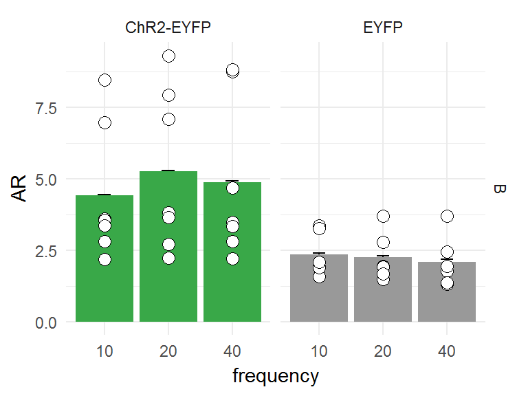

|  | statistic | p.value | method |
| --- | --- | --- | --- |
| 10:ChR2-EYFP | 0.8211 | 0.0659 | Shapiro-Wilk normality test |
| 10:EYFP | 0.8214 | 0.0908 | Shapiro-Wilk normality test |
| 20:ChR2-EYFP | 0.8898 | 0.2734 | Shapiro-Wilk normality test |
| 20:EYFP | 0.8599 | 0.1888 | Shapiro-Wilk normality test |
| 40:ChR2-EYFP | 0.8054 | 0.0463 | Shapiro-Wilk normality test |
| 40:EYFP | 0.8637 | 0.2021 | Shapiro-Wilk normality test |

There is a significant difference in the AR between the two constructs. AR is independent of the frequency of the stimulation in protocol A. No posthoc test is needed as there only are two viral constructs.

```
##                     numDF denDF  F-value p-value
## (Intercept)             1    22 44.20735  <.0001
## construct               1    11  5.65592  0.0366
## frequency               2    22  1.46189  0.2535
## construct:frequency     2    22  2.08240  0.1485
```

## 4.4 Glutamate concentration normalized to milliseconds of stimulation (Ct)

|  | area | construct | frequency | voltage | genotype | pulse | protocol | stimMs | N2 | mean | sd | se |
| --- | --- | --- | --- | --- | --- | --- | --- | --- | --- | --- | --- | --- |
| 2 | GPe | ChR2-EYFP | 10 | 0.7 | Pitx2-Cre | 15 | B | 150 | 7 | 5.52 | 0.58 | 0.22 |
| 4 | GPe | ChR2-EYFP | 20 | 0.7 | Pitx2-Cre | 10 | B | 200 | 7 | 5.37 | 0.55 | 0.21 |
| 6 | GPe | ChR2-EYFP | 40 | 0.7 | Pitx2-Cre | 5 | B | 200 | 7 | 4.46 | 0.69 | 0.26 |
| 8 | GPe | EYFP | 10 | 0.7 | Pitx2-Cre | 15 | B | 150 | 6 | 3.08 | 0.74 | 0.30 |
| 10 | GPe | EYFP | 20 | 0.7 | Pitx2-Cre | 10 | B | 200 | 6 | 2.50 | 0.53 | 0.22 |
| 12 | GPe | EYFP | 40 | 0.7 | Pitx2-Cre | 5 | B | 200 | 6 | 1.73 | 1.03 | 0.42 |

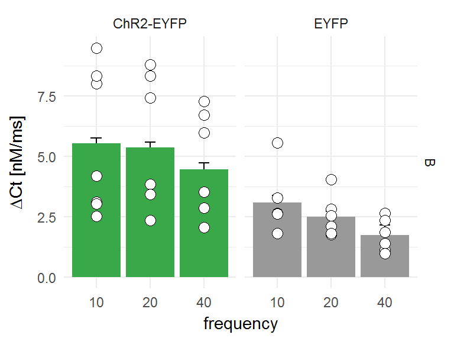

ΔCt is normally distributed in Pitx2-Cre::ChR2-eYFP and Pitx2-Cre::eYFP animals for all frequencies in protocol B. ANOVA can be performed to evaluate differences between the groups.

|  | statistic | p.value | method |
| --- | --- | --- | --- |
| 10:ChR2-EYFP | 0.8385 | 0.0963 | Shapiro-Wilk normality test |
| 10:EYFP | 0.8026 | 0.0621 | Shapiro-Wilk normality test |
| 20:ChR2-EYFP | 0.8437 | 0.1075 | Shapiro-Wilk normality test |
| 20:EYFP | 0.8722 | 0.2350 | Shapiro-Wilk normality test |
| 40:ChR2-EYFP | 0.8725 | 0.1953 | Shapiro-Wilk normality test |
| 40:EYFP | 0.9298 | 0.5782 | Shapiro-Wilk normality test |

There is a significant difference in the ΔCt between the two constructs. ΔCt is frequency-dependent in protocol B.

```
##                     numDF denDF  F-value p-value
## (Intercept)             1    22 48.96213  <.0001
## construct               1    11  5.80263  0.0347
## frequency               2    22 18.06954  <.0001
## construct:frequency     2    22  0.55739  0.5806
```

```
## $lsmeans
##  construct frequency   lsmean        SE df    lower.CL upper.CL
##  ChR2-EYFP 10        5.523649 0.7726947 12  3.84009213 7.207206
##  EYFP      10        3.082245 0.8346056 11  1.26379603 4.900695
##  ChR2-EYFP 20        5.365445 0.7726947 12  3.68188814 7.049002
##  EYFP      20        2.501717 0.8346056 11  0.68326728 4.320166
##  ChR2-EYFP 40        4.463429 0.7726947 12  2.77987206 6.146986
##  EYFP      40        1.729077 0.8346056 11 -0.08937289 3.547526
##
## Confidence level used: 0.95
##
## $contrasts
##  contrast                      estimate        SE df t.ratio p.value
##  ChR2-EYFP,10 - EYFP,10       2.4414037 1.1373757 11   2.147  0.3323
##  ChR2-EYFP,10 - ChR2-EYFP,20  0.1582040 0.2784528 22   0.568  0.9921
##  ChR2-EYFP,10 - EYFP,20       3.0219325 1.1373757 11   2.657  0.1622
##  ChR2-EYFP,10 - ChR2-EYFP,40  1.0602201 0.2784528 22   3.808  0.0108
##  ChR2-EYFP,10 - EYFP,40       3.7945726 1.1373757 11   3.336  0.0563
##  EYFP,10 - ChR2-EYFP,20      -2.2831997 1.1373757 11  -2.007  0.3959
##  EYFP,10 - EYFP,20            0.5805287 0.3007634 22   1.930  0.4113
##  EYFP,10 - ChR2-EYFP,40      -1.3811836 1.1373757 11  -1.214  0.8216
##  EYFP,10 - EYFP,40            1.3531689 0.3007634 22   4.499  0.0022
##  ChR2-EYFP,20 - EYFP,20       2.8637285 1.1373757 11   2.518  0.1991
##  ChR2-EYFP,20 - ChR2-EYFP,40  0.9020161 0.2784528 22   3.239  0.0384
##  ChR2-EYFP,20 - EYFP,40       3.6363686 1.1373757 11   3.197  0.0703
##  EYFP,20 - ChR2-EYFP,40      -1.9617124 1.1373757 11  -1.725  0.5442
##  EYFP,20 - EYFP,40            0.7726402 0.3007634 22   2.569  0.1474
##  ChR2-EYFP,40 - EYFP,40       2.7343526 1.1373757 11   2.404  0.2343
##
## P value adjustment: tukey method for comparing a family of 6 estimates
```

## 4.5 Scatterplot summary for ΔCt, AR and Ĉglu

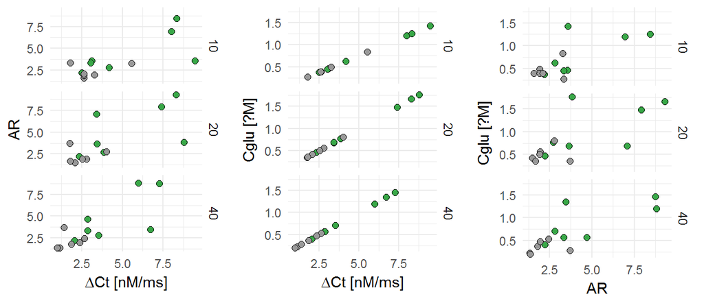

# 5 Direct comparison protocol A and B

## 5.1 ChR2-eYFP animals

### 5.1.1 Ĉglu in protocol A and B in ChR2-eYFP animals

| area | construct | frequency | voltage | genotype | pulse | protocol | stimMs | N2 | mean | sd | se |
| --- | --- | --- | --- | --- | --- | --- | --- | --- | --- | --- | --- |
| GPe | ChR2-EYFP | 10 | 0.7 | Pitx2-Cre | 5 | A | 50 | 7 | 0.27 | 0.21 | 0.08 |
| GPe | ChR2-EYFP | 10 | 0.7 | Pitx2-Cre | 15 | B | 150 | 7 | 0.83 | 0.09 | 0.03 |
| GPe | ChR2-EYFP | 20 | 0.7 | Pitx2-Cre | 5 | A | 100 | 7 | 0.41 | 0.16 | 0.06 |
| GPe | ChR2-EYFP | 20 | 0.7 | Pitx2-Cre | 10 | B | 200 | 7 | 1.07 | 0.11 | 0.04 |
| GPe | ChR2-EYFP | 40 | 0.7 | Pitx2-Cre | 5 | A | 200 | 7 | 0.92 | 0.10 | 0.04 |
| GPe | ChR2-EYFP | 40 | 0.7 | Pitx2-Cre | 5 | B | 200 | 7 | 0.89 | 0.14 | 0.05 |

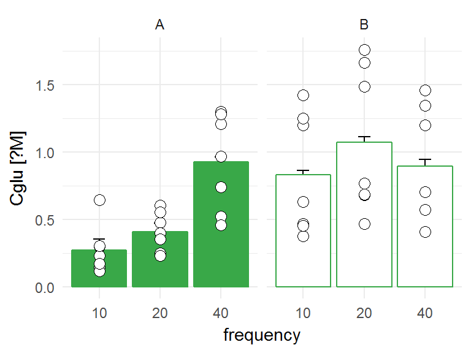

The peak glutamate concentration Ĉglu was already tested for normality and is normally distributed in both protocol A and B.

There is a significant difference between the frequency development in the two different protocols

```
##                    numDF denDF  F-value p-value
## (Intercept)            1    30 33.40013  <.0001
## protocol               1    30 47.52930  <.0001
## frequency              2    30 12.97726   1e-04
## protocol:frequency     2    30 14.18702  <.0001
```

```
## $lsmeans
##  protocol frequency    lsmean       SE df    lower.CL  upper.CL
##  A        10        0.2730351 0.142233  6 -0.07499655 0.6210667
##  B        10        0.8285474 0.142233  6  0.48051572 1.1765790
##  A        20        0.4091411 0.142233  6  0.06110948 0.7571728
##  B        20        1.0730890 0.142233  6  0.72505738 1.4211207
##  A        40        0.9248128 0.142233  6  0.57678118 1.2728445
##  B        40        0.8926858 0.142233  6  0.54465417 1.2407175
##
## Confidence level used: 0.95
##
## $contrasts
##  contrast       estimate         SE df t.ratio p.value
##  A,10 - B,10 -0.55551228 0.09943316 30  -5.587  0.0001
##  A,10 - A,20 -0.13610604 0.09943316 30  -1.369  0.7446
##  A,10 - B,20 -0.80005393 0.09943316 30  -8.046  <.0001
##  A,10 - A,40 -0.65177774 0.09943316 30  -6.555  <.0001
##  A,10 - B,40 -0.61965072 0.09943316 30  -6.232  <.0001
##  B,10 - A,20  0.41940624 0.09943316 30   4.218  0.0026
##  B,10 - B,20 -0.24454166 0.09943316 30  -2.459  0.1687
##  B,10 - A,40 -0.09626546 0.09943316 30  -0.968  0.9244
##  B,10 - B,40 -0.06413844 0.09943316 30  -0.645  0.9864
##  A,20 - B,20 -0.66394790 0.09943316 30  -6.677  <.0001
##  A,20 - A,40 -0.51567170 0.09943316 30  -5.186  0.0002
##  A,20 - B,40 -0.48354468 0.09943316 30  -4.863  0.0005
##  B,20 - A,40  0.14827620 0.09943316 30   1.491  0.6722
##  B,20 - B,40  0.18040321 0.09943316 30   1.814  0.4722
##  A,40 - B,40  0.03212702 0.09943316 30   0.323  0.9995
##
## P value adjustment: tukey method for comparing a family of 6 estimates
```

### 5.1.2 AR in protocol A and B in ChR2-eYFP animals

| area | construct | frequency | voltage | genotype | pulse | protocol | stimMs | N2 | mean | sd | se |
| --- | --- | --- | --- | --- | --- | --- | --- | --- | --- | --- | --- |
| GPe | ChR2-EYFP | 10 | 0.7 | Pitx2-Cre | 5 | A | 50 | 7 | 4.66 | 0.21 | 0.08 |
| GPe | ChR2-EYFP | 10 | 0.7 | Pitx2-Cre | 15 | B | 150 | 7 | 4.41 | 0.09 | 0.03 |
| GPe | ChR2-EYFP | 20 | 0.7 | Pitx2-Cre | 5 | A | 100 | 7 | 3.64 | 0.16 | 0.06 |
| GPe | ChR2-EYFP | 20 | 0.7 | Pitx2-Cre | 10 | B | 200 | 7 | 5.24 | 0.11 | 0.04 |
| GPe | ChR2-EYFP | 40 | 0.7 | Pitx2-Cre | 5 | A | 200 | 7 | 5.37 | 0.10 | 0.04 |
| GPe | ChR2-EYFP | 40 | 0.7 | Pitx2-Cre | 5 | B | 200 | 7 | 4.87 | 0.14 | 0.05 |

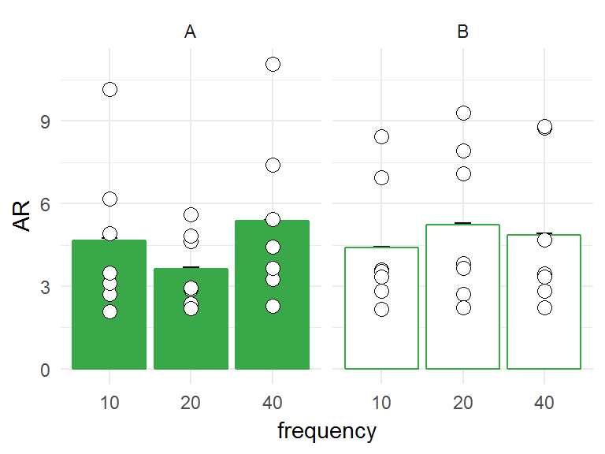

There is no significant difference in AR between the two protocols.

```
##                    numDF denDF  F-value p-value
## (Intercept)            1    30 32.99989  <.0001
## protocol               1    30  0.36632  0.5496
## frequency              2    30  0.80320  0.4573
## protocol:frequency     2    30  1.99287  0.1539
```

### 5.1.3 ΔCt in protocol A and B in ChR2-eYFP animals

| area | construct | frequency | voltage | genotype | pulse | protocol | stimMs | N2 | mean | sd | se |
| --- | --- | --- | --- | --- | --- | --- | --- | --- | --- | --- | --- |
| GPe | ChR2-EYFP | 10 | 0.7 | Pitx2-Cre | 5 | A | 50 | 7 | 5.46 | 4.27 | 1.61 |
| GPe | ChR2-EYFP | 10 | 0.7 | Pitx2-Cre | 15 | B | 150 | 7 | 5.52 | 0.58 | 0.22 |
| GPe | ChR2-EYFP | 20 | 0.7 | Pitx2-Cre | 5 | A | 100 | 7 | 4.09 | 1.64 | 0.62 |
| GPe | ChR2-EYFP | 20 | 0.7 | Pitx2-Cre | 10 | B | 200 | 7 | 5.37 | 0.55 | 0.21 |
| GPe | ChR2-EYFP | 40 | 0.7 | Pitx2-Cre | 5 | A | 200 | 7 | 4.62 | 0.50 | 0.19 |
| GPe | ChR2-EYFP | 40 | 0.7 | Pitx2-Cre | 5 | B | 200 | 7 | 4.46 | 0.69 | 0.26 |

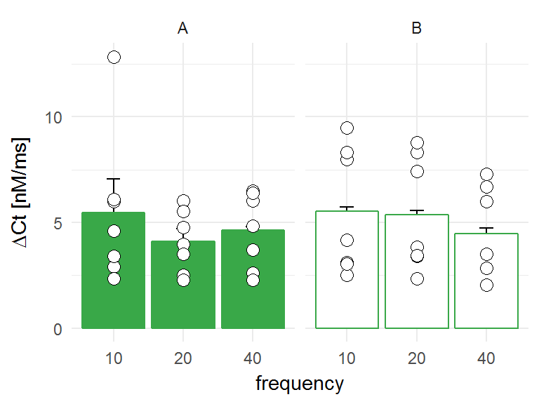

There is no significant difference in ΔCt between the two protocols.

```
##                    numDF denDF  F-value p-value
## (Intercept)            1    30 32.66907  <.0001
## protocol               1    30  1.08774  0.3053
## frequency              2    30  2.38479  0.1094
## protocol:frequency     2    30  1.40507  0.2610
```

### 5.1.4 Summary in protocol A and B in ChR2-eYFP animals

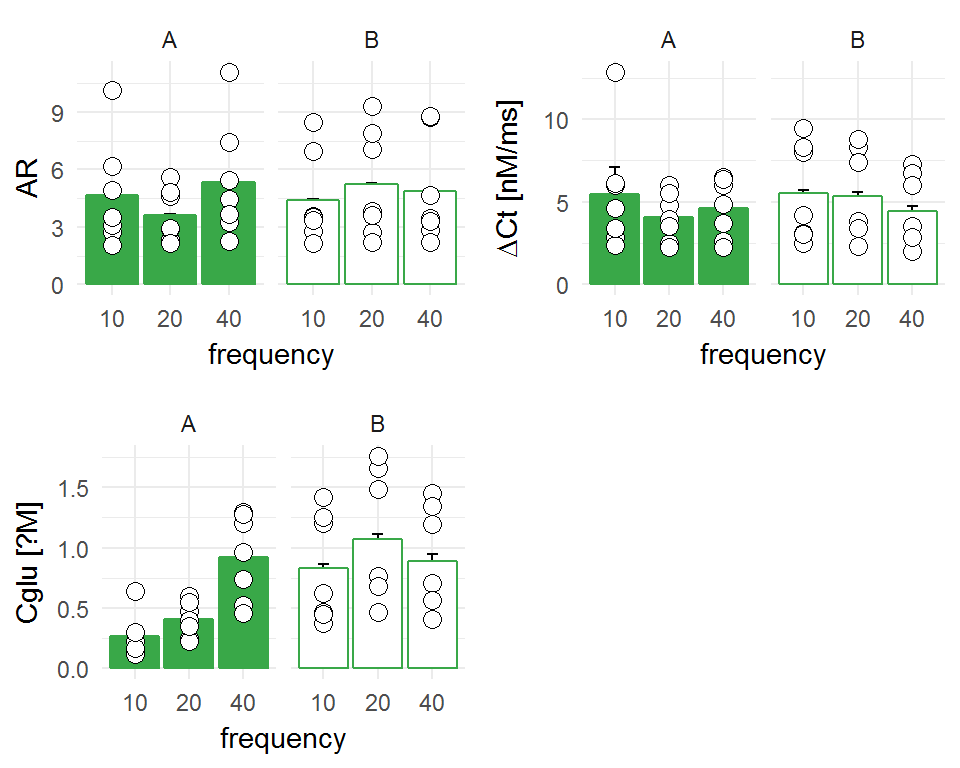

## 5.2 eYFP animals

### 5.2.1 Ĉglu in protocol A and B in eYFP animals

|  | area | construct | frequency | voltage | genotype | pulse | protocol | stimMs | N2 | mean | sd | se |
| --- | --- | --- | --- | --- | --- | --- | --- | --- | --- | --- | --- | --- |
| 7 | GPe | EYFP | 10 | 0.7 | Pitx2-Cre | 5 | A | 50 | 6 | 0.08 | 0.10 | 0.04 |
| 8 | GPe | EYFP | 10 | 0.7 | Pitx2-Cre | 15 | B | 150 | 6 | 0.46 | 0.11 | 0.05 |
| 9 | GPe | EYFP | 20 | 0.7 | Pitx2-Cre | 5 | A | 100 | 6 | 0.22 | 0.07 | 0.03 |
| 10 | GPe | EYFP | 20 | 0.7 | Pitx2-Cre | 10 | B | 200 | 6 | 0.50 | 0.11 | 0.04 |
| 11 | GPe | EYFP | 40 | 0.7 | Pitx2-Cre | 5 | A | 200 | 6 | 0.44 | 0.09 | 0.04 |
| 12 | GPe | EYFP | 40 | 0.7 | Pitx2-Cre | 5 | B | 200 | 6 | 0.35 | 0.21 | 0.08 |

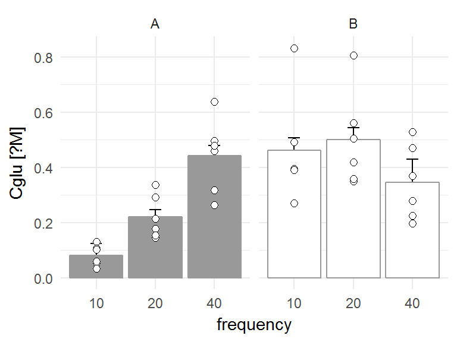

The peak glutamate concentration Ĉglu was already tested for normality and is normally distributed in both protocol A and B. There is a significant difference between the frequency development in the two different protocols

```
##                    numDF denDF  F-value p-value
## (Intercept)            1    25 55.05282  <.0001
## protocol               1    25 46.21878  <.0001
## frequency              2    25  6.99488  0.0039
## protocol:frequency     2    25 27.74732  <.0001
```

```
## $lsmeans
##  protocol frequency     lsmean         SE df    lower.CL  upper.CL
##  A        10        0.08143816 0.05551405  5 -0.06126527 0.2241416
##  B        10        0.46233682 0.05551405  5  0.31963340 0.6050402
##  A        20        0.22044803 0.05551405  5  0.07774461 0.3631514
##  B        20        0.50034334 0.05551405  5  0.35763992 0.6430468
##  A        40        0.44314768 0.05551405  5  0.30044425 0.5858511
##  B        40        0.34581530 0.05551405  5  0.20311188 0.4885187
##
## Confidence level used: 0.95
##
## $contrasts
##  contrast       estimate         SE df t.ratio p.value
##  A,10 - B,10 -0.38089866 0.04785138 25  -7.960  <.0001
##  A,10 - A,20 -0.13900987 0.04785138 25  -2.905  0.0729
##  A,10 - B,20 -0.41890518 0.04785138 25  -8.754  <.0001
##  A,10 - A,40 -0.36170952 0.04785138 25  -7.559  <.0001
##  A,10 - B,40 -0.26437715 0.04785138 25  -5.525  0.0001
##  B,10 - A,20  0.24188879 0.04785138 25   5.055  0.0004
##  B,10 - B,20 -0.03800652 0.04785138 25  -0.794  0.9659
##  B,10 - A,40  0.01918914 0.04785138 25   0.401  0.9985
##  B,10 - B,40  0.11652151 0.04785138 25   2.435  0.1826
##  A,20 - B,20 -0.27989531 0.04785138 25  -5.849  0.0001
##  A,20 - A,40 -0.22269965 0.04785138 25  -4.654  0.0012
##  A,20 - B,40 -0.12536727 0.04785138 25  -2.620  0.1294
##  B,20 - A,40  0.05719566 0.04785138 25   1.195  0.8349
##  B,20 - B,40  0.15452804 0.04785138 25   3.229  0.0361
##  A,40 - B,40  0.09733237 0.04785138 25   2.034  0.3524
##
## P value adjustment: tukey method for comparing a family of 6 estimates
```

### 5.2.2 AR in protocol A and B in eYFP animals

|  | area | construct | frequency | voltage | genotype | pulse | protocol | stimMs | N2 | mean | sd | se |
| --- | --- | --- | --- | --- | --- | --- | --- | --- | --- | --- | --- | --- |
| 7 | GPe | EYFP | 10 | 0.7 | Pitx2-Cre | 5 | A | 50 | 6 | 1.64 | 0.10 | 0.04 |
| 8 | GPe | EYFP | 10 | 0.7 | Pitx2-Cre | 15 | B | 150 | 6 | 2.35 | 0.11 | 0.05 |
| 9 | GPe | EYFP | 20 | 0.7 | Pitx2-Cre | 5 | A | 100 | 6 | 2.28 | 0.07 | 0.03 |
| 10 | GPe | EYFP | 20 | 0.7 | Pitx2-Cre | 10 | B | 200 | 6 | 2.25 | 0.11 | 0.04 |
| 11 | GPe | EYFP | 40 | 0.7 | Pitx2-Cre | 5 | A | 200 | 6 | 2.19 | 0.09 | 0.04 |
| 12 | GPe | EYFP | 40 | 0.7 | Pitx2-Cre | 5 | B | 200 | 6 | 2.09 | 0.21 | 0.08 |

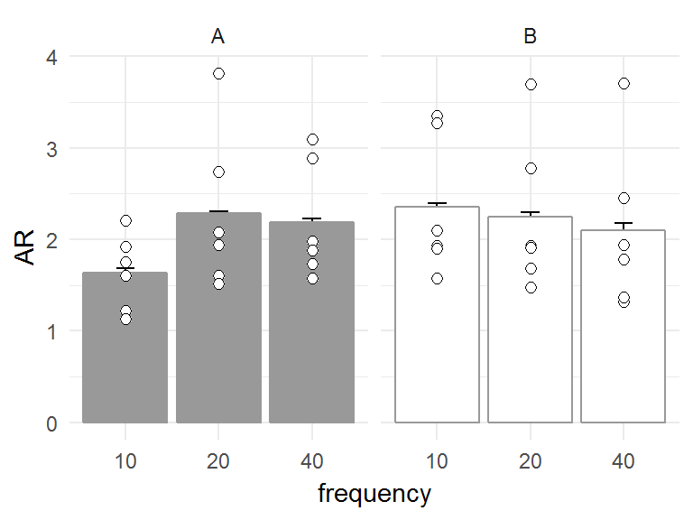

There exists an interaction between the protocol and frequency in the Pitx2-Cre::eYFP animals. Significant difference between protocol 1, 10 Hz and protocol 2 10, 20 Hz.

```
##                    numDF denDF  F-value p-value
## (Intercept)            1    25 56.82403  <.0001
## protocol               1    25  3.27365  0.0824
## frequency              2    25  2.10336  0.1431
## protocol:frequency     2    25  5.87894  0.0081
```

```
## $lsmeans
##  protocol frequency   lsmean        SE df  lower.CL upper.CL
##  A        10        1.638213 0.3075823  5 0.8475481 2.428879
##  B        10        2.352595 0.3075823  5 1.5619295 3.143260
##  A        20        2.282231 0.3075823  5 1.4915655 3.072896
##  B        20        2.247737 0.3075823  5 1.4570717 3.038403
##  A        40        2.190988 0.3075823  5 1.4003227 2.981653
##  B        40        2.094453 0.3075823  5 1.3037881 2.885119
##
## Confidence level used: 0.95
##
## $contrasts
##  contrast       estimate        SE df t.ratio p.value
##  A,10 - B,10 -0.71438143 0.1861464 25  -3.838  0.0087
##  A,10 - A,20 -0.64401747 0.1861464 25  -3.460  0.0214
##  A,10 - B,20 -0.60952363 0.1861464 25  -3.274  0.0326
##  A,10 - A,40 -0.55277460 0.1861464 25  -2.970  0.0636
##  A,10 - B,40 -0.45624002 0.1861464 25  -2.451  0.1774
##  B,10 - A,20  0.07036396 0.1861464 25   0.378  0.9989
##  B,10 - B,20  0.10485780 0.1861464 25   0.563  0.9926
##  B,10 - A,40  0.16160684 0.1861464 25   0.868  0.9506
##  B,10 - B,40  0.25814142 0.1861464 25   1.387  0.7342
##  A,20 - B,20  0.03449384 0.1861464 25   0.185  1.0000
##  A,20 - A,40  0.09124288 0.1861464 25   0.490  0.9961
##  A,20 - B,40  0.18777746 0.1861464 25   1.009  0.9106
##  B,20 - A,40  0.05674904 0.1861464 25   0.305  0.9996
##  B,20 - B,40  0.15328362 0.1861464 25   0.823  0.9603
##  A,40 - B,40  0.09653458 0.1861464 25   0.519  0.9949
##
## P value adjustment: tukey method for comparing a family of 6 estimates
```

### 5.2.3 ΔCt in protocol A and B in eYFP animals

|  | area | construct | frequency | voltage | genotype | pulse | protocol | stimMs | N2 | mean | sd | se |
| --- | --- | --- | --- | --- | --- | --- | --- | --- | --- | --- | --- | --- |
| 7 | GPe | EYFP | 10 | 0.7 | Pitx2-Cre | 5 | A | 50 | 6 | 1.63 | 2.07 | 0.85 |
| 8 | GPe | EYFP | 10 | 0.7 | Pitx2-Cre | 15 | B | 150 | 6 | 3.08 | 0.74 | 0.30 |
| 9 | GPe | EYFP | 20 | 0.7 | Pitx2-Cre | 5 | A | 100 | 6 | 2.20 | 0.66 | 0.27 |
| 10 | GPe | EYFP | 20 | 0.7 | Pitx2-Cre | 10 | B | 200 | 6 | 2.50 | 0.53 | 0.22 |
| 11 | GPe | EYFP | 40 | 0.7 | Pitx2-Cre | 5 | A | 200 | 6 | 2.22 | 0.45 | 0.18 |
| 12 | GPe | EYFP | 40 | 0.7 | Pitx2-Cre | 5 | B | 200 | 6 | 1.73 | 1.03 | 0.42 |

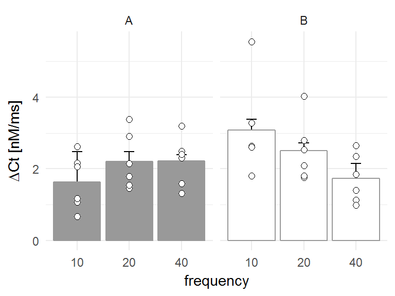

There is a significant difference in ΔCt between the two protocols and an interaction between protocol and frequency. In protocol 1, 10 Hz ΔCt is smaller than 2, 10 Hz and in protocol 2, 10 Hz it is larger than in protocol 2 at 40 Hz.

```
##                    numDF denDF  F-value p-value
## (Intercept)            1    25 55.72737  <.0001
## protocol               1    25  6.10791  0.0206
## frequency              2    25  2.23007  0.1285
## protocol:frequency     2    25 10.92416  0.0004
```

```
## $lsmeans
##  protocol frequency   lsmean      SE df  lower.CL upper.CL
##  A        10        1.628763 0.35402  5 0.7187258 2.538800
##  B        10        3.082245 0.35402  5 2.1722081 3.992283
##  A        20        2.204480 0.35402  5 1.2944429 3.114518
##  B        20        2.501717 0.35402  5 1.5916793 3.411754
##  A        40        2.215738 0.35402  5 1.3057010 3.125776
##  B        40        1.729077 0.35402  5 0.8190392 2.639114
##
## Confidence level used: 0.95
##
## $contrasts
##  contrast       estimate        SE df t.ratio p.value
##  A,10 - B,10 -1.45348233 0.2952975 25  -4.922  0.0006
##  A,10 - A,20 -0.57571718 0.2952975 25  -1.950  0.3975
##  A,10 - B,20 -0.87295358 0.2952975 25  -2.956  0.0655
##  A,10 - A,40 -0.58697527 0.2952975 25  -1.988  0.3768
##  A,10 - B,40 -0.10031341 0.2952975 25  -0.340  0.9993
##  B,10 - A,20  0.87776515 0.2952975 25   2.972  0.0632
##  B,10 - B,20  0.58052875 0.2952975 25   1.966  0.3885
##  B,10 - A,40  0.86650706 0.2952975 25   2.934  0.0686
##  B,10 - B,40  1.35316892 0.2952975 25   4.582  0.0014
##  A,20 - B,20 -0.29723640 0.2952975 25  -1.007  0.9114
##  A,20 - A,40 -0.01125808 0.2952975 25  -0.038  1.0000
##  A,20 - B,40  0.47540377 0.2952975 25   1.610  0.5999
##  B,20 - A,40  0.28597832 0.2952975 25   0.968  0.9236
##  B,20 - B,40  0.77264018 0.2952975 25   2.616  0.1302
##  A,40 - B,40  0.48666186 0.2952975 25   1.648  0.5764
##
## P value adjustment: tukey method for comparing a family of 6 estimates
```

### 5.2.4 Summary in protocol A and B in eYFP animals

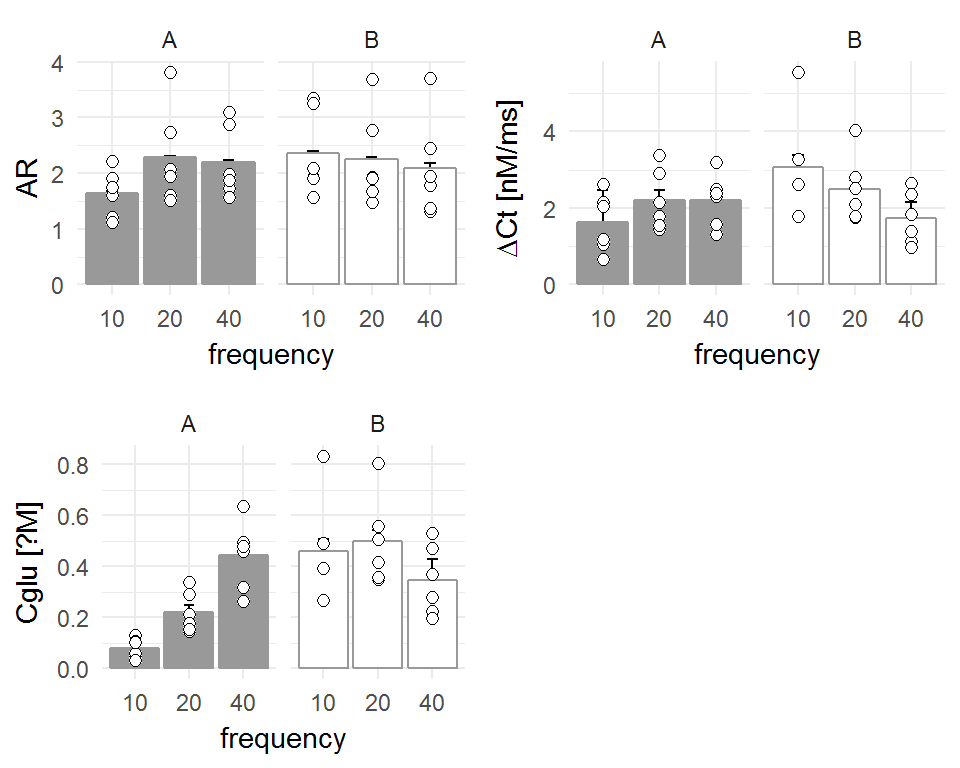